# 08 - Cutaneous Neurofibroma Tumor Growht and Immune Cor

Sara Gosline

2019-10-13

## Synapse tables with data

We have two tables on synapse that have cNF patient data in them - [Patient Table](https://www.synapse.org/#!Synapse:syn7342635/tables/) - [Sample Table](https://www.synapse.org/#!Synapse:syn5556216/tables/)

We also have Immune Data - [Tumor Deconvolution Table](https://www.synapse.org/#!Synapse:syn20710536/tables/)

Let’s see if there are any correlations between immune populations and tumor growth.

```r
pat.tab<-synapser::synTableQuery("SELECT Patient,Race,Gender,Age,Pain,Itching FROM syn7342635")$asDataFrame()%>%
  select(-c(ROW_ID,ROW_VERSION))
```

```
##
 [####################]100.00%   1/1   Done...
Downloading  [####################]100.00%   616.0bytes/616.0bytes (161.5kB/s) Job-98309147915215270017646377.csv Done...
```

```r
samp.tab<-synapser::synTableQuery("SELECT Patient,TumorNumber,Length_in_mm FROM syn5556216")$asDataFrame()%>%
  select(-c(ROW_ID,ROW_VERSION))
```

```
##
 [####################]100.00%   1/1   Done...
Downloading  [####################]100.00%   1.4kB/1.4kB (2.2MB/s) Job-98309152569397727354925106.csv Done...
```

## Merge data together

For the purposes of this analysis we want to have just the age, sex, tumor size and and ‘reformed’ patient name

```r
full.tab<-samp.tab%>%left_join(pat.tab,by='Patient')%>%
  mutate(specimenID=paste0('patient',Patient,'tumor',TumorNumber))
DT::datatable(full.tab)
```

|  | Patient | TumorNumber | Length_in_mm | Race | Gender | Age | Pain | Itching | specimenID |
| --- | --- | --- | --- | --- | --- | --- | --- | --- | --- |
| 1 | 1 | 3 |  | White | Female | 48 | False | True | patient1tumor3 |
| 2 | 1 | 4 | 14 | White | Female | 48 | False | True | patient1tumor4 |
| 3 | 1 | 6 | 14 | White | Female | 48 | False | True | patient1tumor6 |
| 4 | 1 | 9 | 15 | White | Female | 48 | False | True | patient1tumor9 |
| 5 | 1 | 1 | 15 | White | Female | 48 | False | True | patient1tumor1 |
| 6 | 1 | 2 | 13 | White | Female | 48 | False | True | patient1tumor2 |
| 7 | 2 | 4 | 7 | Asian | Female | 34 | False | False | patient2tumor4 |
| 8 | 2 | 6 | 6 | Asian | Female | 34 | False | False | patient2tumor6 |
| 9 | 2 | 7 | 5 | Asian | Female | 34 | False | False | patient2tumor7 |
| 10 | 2 | 10 | 7 | Asian | Female | 34 | False | False | patient2tumor10 |

[output cut: 58 more lines]

Now we can get the immune data!

## Collect Immune Data

Now we can download the imune data and evaluate any correlations betwen scores and tumor size

```r
imm.data<-synTableQuery("SELECT * FROM syn20710536 where tumorType='Cutaneous Neurofibroma'")$asDataFrame()
```

```
##
 [####################]100.00%   1/1   Done...
Downloading  [####################]100.00%   265.4kB/265.4kB (625.6kB/s) Job-98309164243089157346811320.csv Done...
```

```r
data.with.var<-imm.data%>%left_join(full.tab,by='specimenID')

#now coampute the correlation with size for each transcript...?
tum.cors=data.with.var%>%group_by(method,cell_type)%>%
  mutate(corVal=cor(score,Length_in_mm))%>%
  arrange(desc(abs(corVal)))%>%
  select(cell_type,method,corVal)%>%distinct()

DT::datatable(tum.cors)
```

|  | cell_type | method | corVal |
| --- | --- | --- | --- |
| 1 | Cancer associated fibroblast | xcell | 0.491636397015061 |
| 2 | Dendritic cell resting | cibersort | -0.485378367523621 |
| 3 | Macrophage M1 | cibersort | 0.476730533517376 |
| 4 | NK cell | mcp_counter | 0.475208377000457 |
| 5 | Dendritic cell activated | cibersort | -0.422625547013788 |
| 6 | Macrophage M2 | cibersort | 0.418718573033439 |
| 7 | Macrophage M2 | xcell | 0.402029909146382 |
| 8 | Endothelial cell | mcp_counter | 0.375819422960968 |
| 9 | Dendritic cell | xcell | -0.37180611175652 |
| 10 | Monocyte | mcp_counter | 0.371677571848092 |

[output cut: 39 more lines]

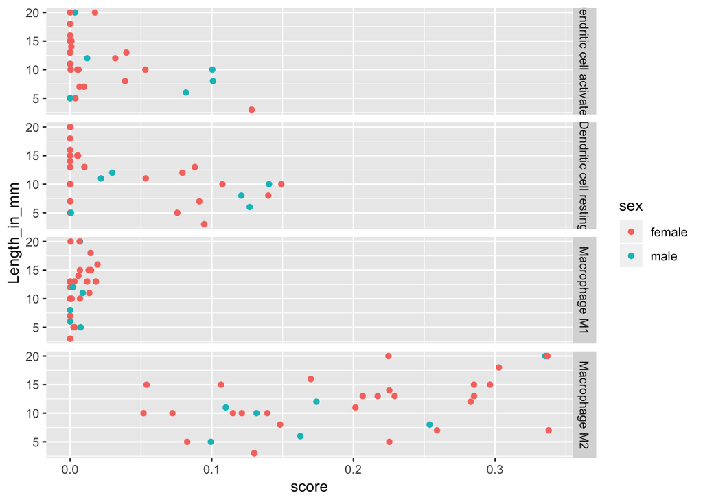

```r
cs.cells=subset(tum.cors,abs(corVal)>0.35)%>%
    subset(method=='cibersort')%>%ungroup()%>%
    select(cell_type)%>%unlist()

subset(data.with.var,method=='cibersort')%>%
    subset(cell_type%in%cs.cells)%>%
    ggplot()+geom_point(aes(x=score,y=Length_in_mm,col=sex))+facet_grid(cell_type~.)
```

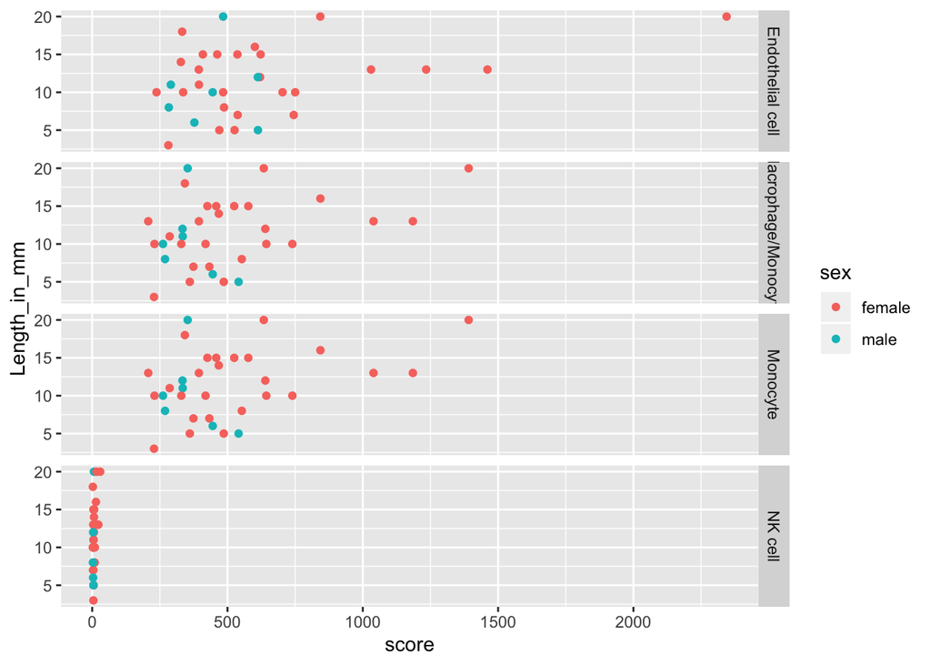

```r
mc.cells=subset(tum.cors,abs(corVal)>0.35)%>%
    subset(method=='mcp_counter')%>%ungroup()%>%
    select(cell_type)%>%unlist()

subset(data.with.var,method=='mcp_counter')%>%
    subset(cell_type%in%mc.cells)%>%
    ggplot()+geom_point(aes(x=score,y=Length_in_mm,col=sex))+facet_grid(cell_type~.)
```

So it seems like the dendritic cells, monocytes, and macrophages seem to have a weak role in tumor growth.

## Any correlation with itching

Perhaps itching is driving this?

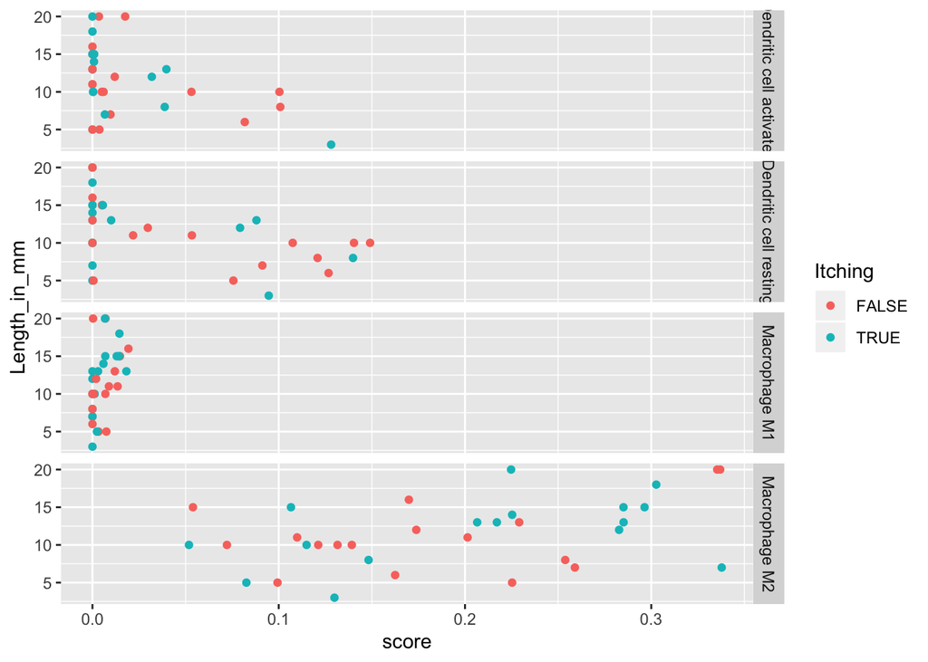

```r
subset(data.with.var,method=='cibersort')%>%
    subset(cell_type%in%cs.cells)%>%
    ggplot()+geom_point(aes(x=score,y=Length_in_mm,col=Itching))+facet_grid(cell_type~.)
```

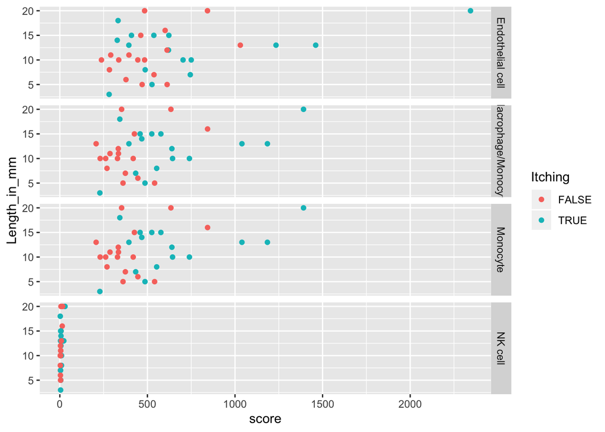

```r
subset(data.with.var,method=='mcp_counter')%>%
    subset(cell_type%in%mc.cells)%>%
    ggplot()+geom_point(aes(x=score,y=Length_in_mm,col=Itching))+facet_grid(cell_type~.)
```

Doesn’t seem to be. But we can do a test to see if Itching is correlated

```r
data.with.var%>%select(Pain,Itching)%>%distinct()
```

```
##    Pain Itching
## 1 FALSE   FALSE
## 2  TRUE    TRUE
## 3 FALSE    TRUE
```

```r
#it seems patients who have pain also have itching, so will only evaluate itching
sig.vals<-data.with.var%>%
  spread(key=Itching,value=score)%>%
  group_by(method,cell_type)%>%
  mutate(pval=wilcox.test(`TRUE`,`FALSE`)$p.value)%>%
  select(method,cell_type,pval)%>%distinct()%>%
  ungroup()

#there are some?!
DT::datatable(subset(sig.vals,pval<0.05))
```

|  | method | cell_type | pval |
| --- | --- | --- | --- |
| 1 | mcp_counter | Monocyte | 0.0024781901721191 |
| 2 | mcp_counter | Macrophage/Monocyte | 0.0024781901721191 |
| 3 | mcp_counter | Neutrophil | 0.0024781901721191 |
| 4 | mcp_counter | Cancer associated fibroblast | 0.00608087340459694 |
| 5 | xcell | T cell CD4+ memory | 0.025304334336236 |

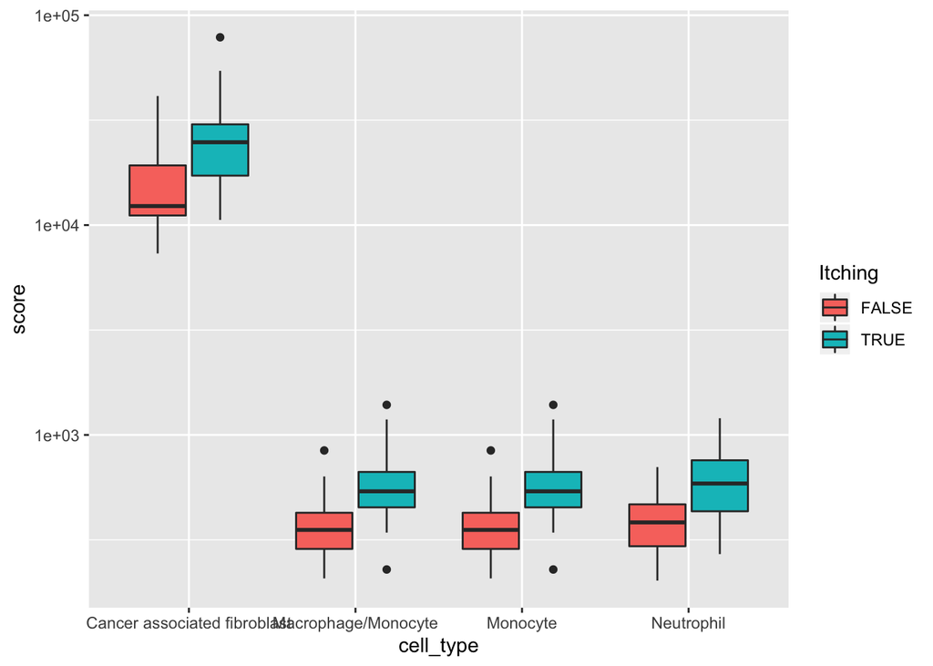

```r
subset(data.with.var,method=='mcp_counter')%>%
  subset(cell_type%in%subset(sig.vals,pval<0.05)$cell_type)%>%
  ggplot()+geom_boxplot(aes(x=cell_type,y=score,fill=Itching))+scale_y_log10()
```

## Next steps

Not sure what else we can do with these. Some ideas:

- Look to see if these cell types are up-regulated in pNFs that become MPNSTs
- Look to see if these cell types are different between pNFs and MPNSTs